# Lexical of 20th century Odyssey translations (Part B): Etymologies

## **Road Map**

**I. Libraries, files, and paths**

**II. Etymological Expectations**

1. Bibliographic information about the translators
2. The translators at a glance tokenwise

**III. Etymology Analysis**

# **Approaching the Etymologies of the Odyssey**

The topic of etymology is more complex than appears at first. Between morphology and semantic changes, tracing the transformation of a word requieres philological caution. There are cases in which, even taking that minute care of the philologist, there aren't a scholar consensus regarding a word's origin.

A programatic approach that catches all the words in a sample with some precision is a daunting task. I attempted to do this here, using the most complete etymologycal dictionary in Egnlish and creating functions to assign their etymological label to each token in the six translations of the Odyssey.

A notorious limitation of this first approach is that most of the etymologies in this six million plus entries dictionary(based on Wiktionary:Etymology) still are a recursive deadend in which a eng: word leads to the same eng: word. the silver lining is that this handicap is democratic, i.e., normally distributed across the translations, so they share the downside.

**The road map**

- Getting the Odysseys and etimologies (loading data)
- Mapping words to their etymology
- Getting the word-etymology frequencies by book
  - Show distributions with plots
- Compare etymological distributions across authors
  - Scale the frequencies to minimize the effect zise of token lenght
  - Focus on the five most important:
    - eng: English
    - enm: Middle English
    - ang: Anglo-Saxon
    - lat: Latin
    - xno: Old Norman
    - *plus:* `grc:` Ancient Greek (because of the Odyssey)
  - Compare authors side-by-side:
    - Origins across books: Fitzgerald and Wilson
    - Zooming in selected categories: `enm`, `ang` & `lat` across books

**Future Version**

- Adding baseline: Woolf's *A Voyage Out*
- Hypothesis testing
  - ANOVA to compare multiple distributions
    - H0: There is NOT significant etymological differnece between the authors
    - H1: There is SIGNIFICANT etymological differnece between the authors

Melo's dictionary doesn't follow the expected etymological distribution of English, equal parts of **Latin**, **French** (Middle-French and Anglo-French/Anglo-Norman included), and **Germanic** (Old German, Old Norse, Anglo-Saxon included). This is because, as I mentioned above, in many cases following a word programmatically falls back to its English label. This is true of the dictionary's structure as it's true of my function.

[figure not shown]

*English **Roots** Pie*

```python
import autotime # Provision for anxious people
%load_ext autotime
```

```
time: 66.4 μs (started: 2025-04-22 02:19:37 +02:00)
```

```python
# ----------------------------------------------------------------------
# Baic Libraries
# ----------------------------------------------------------------------

import sys
import os

import ast
from collections import Counter
from collections import defaultdict
from itertools import combinations

import re
import nltk

import numpy as np
import pandas as pd

import statsmodels.formula.api as smf
import statsmodels.api as sm
import scipy.stats as stats
from scipy.stats import shapiro, kstest, normaltest
from scipy.spatial.distance import cosine

from sklearn.feature_extraction.text import TfidfVectorizer
from sklearn.decomposition import PCA
from sklearn.preprocessing import StandardScaler
import scipy.cluster.hierarchy as sch
```

```
time: 2.02 s (started: 2025-04-22 02:19:37 +02:00)
```

```python
# ----------------------------------------------------------------------
# Personalized Visualization & Functions
# ----------------------------------------------------------------------

sys.path.append('/Users/debr/English-Homer/functions')
import matplotlib.pyplot as plt
import seaborn as sns
from matplotlib.colors import LinearSegmentedColormap

import e_chroma as chroma # My Vizualization library
import e_plots as oz      # My custom plots library
import e_pandisplay as pan# My pandas display options

import e_nlp_ody as e     # Import my nlp functions

import warnings           # Nononsense provision
warnings.filterwarnings('ignore')
```

[output not shown]

```python
# ----------------------------------------------------------------------
# File management
# ----------------------------------------------------------------------

# TO UPDATE
nb_id = "lexical_B01"

output_path = f"./"
os.makedirs(os.path.dirname(output_path), exist_ok=True)
output_path_plots = f"./{output_path}/{nb_id}_plots/"
os.makedirs(os.path.dirname(output_path_plots), exist_ok=True)
chroma.set_output_path(output_path_plots)
```

```
Output path set to: ././/lexical_B01_plots/
time: 659 μs (started: 2025-04-22 02:19:40 +02:00)
```

```python
# ----------------------------------------------------------------------
# Odysseys
# ----------------------------------------------------------------------

translators = ['AT_Murray', 'Fitzgerald', 'Lattimore', 'Fagles', 'Wilson', 'Green', 'Woolf']

dfs = []

for odyssey in translators:
    filepath = f"/Users/debr/odysseys_en/dataframed/Odyssey_{odyssey}_DataFrame.csv"
    temp_df = pd.read_csv(filepath)
    dfs.append(temp_df)  # Append it to the list

df = pd.concat(dfs, axis=0, ignore_index=True)

df["text"] = df["text"].apply(ast.literal_eval)
df["tokens"] = df["tokens"].apply(ast.literal_eval)
df['translator'] = pd.Categorical(df['author'])
df["book_num"] = pd.Categorical(df["book_num"])
df = df[['translator', 'book_num', 'text', 'tokens', 'num_words', 'num_tokens']]

# ----------------------------------------------------------------------
# Backup dataframe only 'translator', 'book_num', 'text', 'tokens', columns
# ----------------------------------------------------------------------
df_bkp = df[['translator', 'book_num', 'text', 'tokens']].copy()
# ----------------------------------------------------------------------
# Dataframe check
# ----------------------------------------------------------------------

e.check_df(df)
```

```
Mr righteous here has no missing values!

* df columns: Index(['translator', 'book_num', 'text', 'tokens', 'num_words', 'num_tokens'], dtype='object')

* Shape: (168, 6)

* Total memory in MB: 4.064749
time: 698 ms (started: 2025-04-22 02:19:40 +02:00)
```

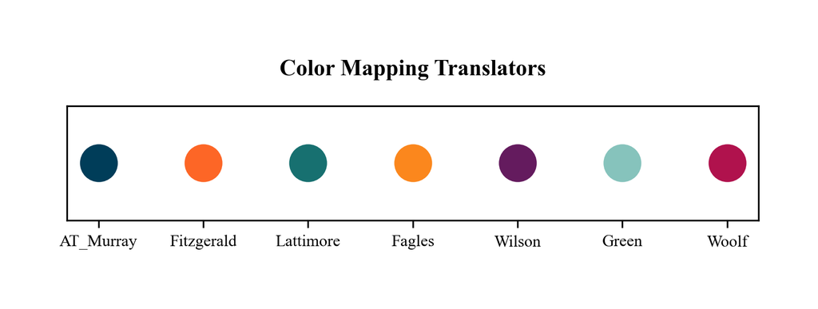

```
time: 153 ms (started: 2025-04-22 02:19:40 +02:00)
```

```python
# ----------------------------------------------------------------------
# Create a color mapping for translators
# ----------------------------------------------------------------------

translators = df["translator"].unique()
palette = {translator: color for translator,
           color in zip(translators, chroma.color_palette.values())}

plt.figure(figsize=(6, 1))

for i, (translator, color) in enumerate(palette.items()):
    plt.scatter(i, 0, color=color, s=300)

plt.xticks(range(len(palette)), palette.keys(), fontsize=8)
plt.yticks([])
plt.title("Color Mapping Translators", fontsize=11)
plt.savefig(f"{output_path_plots}translator_color_mapping-{nb_id}.png")
plt.show()
```

## **2. The Dictionaries

Python etymologies package is Ety. It is based on Melo's dictionary. However, it doesn't works as expected. So I had to came up with my own solution.

This is the data-dictionary.

Etymological Wordnet 2013-02-08 Gerard de Melo http://icsi.berkeley.edu/~demelo/etymwn/

== DESCRIPTION ==

The Etymological Wordnet project provides information about how words in different languages are etymologically related. The information is mostly mined from the English version of Wiktionary, but also contains a number of manual additions.

== FORMAT ==

The package includes a Tab-separated values (TSV) file in UTF-8 format with three columns, providing a word, a relation, and a target word. Words are given with ISO 639-3 codes (additionally, there are some ISO 639-2 codes prefixed with "p_" to indicate proto-languages). The most relevant relation is "rel:etymology". To see only etymological relations, run grep "rel:etymology" etymwn.tsv | less on UNIX-based systems.

== CREDITS AND LICENSE ==

Gerard de Melo http://icsi.berkeley.edy/~demelo/ Based on the contributions of the English Wiktionary community http://en.wiktionary.org/

License: CC-BY-SA 3.0

In scientific works, please cite: Gerard de Melo, Gerhard Weikum. "Towards Universal Multilingual Knowledge Bases". In: Principles, Construction, and Applications of Multilingual Wordnets. Proceedings of the 5th Global Wordnet Conference (GWC 2010). Narosa Publishing 2010, New Delhi India.

### Working with ety

```python
# ----------------------------------------------------------------------
# Probing ety
# ----------------------------------------------------------------------
import ety
# Get the etymology of the word "muse" in English
word = "muse"
ety_origin = ety.origins(word)
ety_tree = ety.tree(word)
print(f"Etymology of '{word}': {ety_origin}")
print(f"Etymology tree of '{word}': {ety_tree}")
```

```
Etymology of 'muse': [Word(muse, Middle French (ca. 1400-1600) [frm])]
Etymology tree of 'muse': muse (English)
└── muse (Middle French (ca. 1400-1600))
    └── Musa (Latin)
        └── Μοῦσα (Ancient Greek (to 1453))
time: 528 ms (started: 2025-04-22 02:19:40 +02:00)
```

```python
# Get the etymology of the word "table" in English

word = "table"
ety_origin = ety.origins(word)
ety_tree = ety.tree(word)
print(f"Etymology of '{word}': {ety_origin}")
print(f"Etymology tree of '{word}': {ety_tree}")
```

```
Etymology of 'table': [Word(table, Middle English (1100-1500) [enm])]
Etymology tree of 'table': table (English)
└── table (Middle English (1100-1500))
time: 517 μs (started: 2025-04-22 02:19:41 +02:00)
```

### Developing a dictionary we can use

```python
# ----------------------------------------------------------------------
# Getting the full dictionary
# ----------------------------------------------------------------------

etymologypath = "/Users/debr/odysseys_en/etymwn-20130208/etymwn.tsv"

etymology_df = pd.read_csv(etymologypath, sep="\t", names=["word", "relation", "target_word"], encoding="utf-8")
etymology_df["relation"] = etymology_df["relation"].astype("category") # to save space

e.check_df(etymology_df)
```

```
Mr righteous here has no missing values!

* df columns: Index(['word', 'relation', 'target_word'], dtype='object')

* Shape: (6031431, 3)

* Total memory in MB: 922.924706
time: 4.72 s (started: 2025-04-22 02:19:41 +02:00)
```

```python
etymology_df.sample(10, random_state=402)
```

|  | word | relation | target_word |
| --- | --- | --- | --- |
| 5463534 | spa: condicional | rel:has_derived_form | spa: condicionales |
| 467142 | eng: albuminization | rel:etymologically_related | eng: toxalbumin |
| 2075742 | fra: insulteur | rel:etymologically_related | fra: insulteuse |
| 4897623 | lat: torculo | rel:has_derived_form | lat: torculavissent |
| 255143 | deu: anfangen | rel:has_derived_form | deu: anfingt |
| 4675182 | lat: prodicimini | rel:is_derived_from | lat: prodico |
| 1992445 | fra: enflai | rel:is_derived_from | fra: enfler |
| 5773738 | spa: sobrecargasen | rel:is_derived_from | spa: sobrecargar |
| 4882662 | lat: taedeo | rel:has_derived_form | lat: taedueritis |
| 5357602 | spa: aclaraseis | rel:is_derived_from | spa: aclarar |

```
time: 133 ms (started: 2025-04-22 02:19:46 +02:00)
```

```python
relations = [etymology_df['relation'].unique()]
relations
```

```
[['rel:etymological_origin_of', 'rel:has_derived_form', 'rel:is_derived_from', 'rel:etymology', 'rel:etymologically_related', 'rel:variant:orthography', 'rel:derived', 'rel:etymologically']
 Categories (8, object): ['rel:derived', 'rel:etymological_origin_of', 'rel:etymologically', 'rel:etymologically_related', 'rel:etymology', 'rel:has_derived_form', 'rel:is_derived_from', 'rel:variant:orthography']]
```

```
time: 57.4 ms (started: 2025-04-22 02:19:46 +02:00)
```

**Description of categories**

| Relation | Description |
| --- | --- |
| **rel:etymological_origin_of** | Indicates that a word is the root or ancestor of another word. Example: Latin *scientia* is the etymological origin of English *science*. |
| **rel:has_derived_form** | Shows that a word has a derived variant. Example: *happy* has the derived form *happiness*. |
| **rel:is_derived_from** | Specifies that a word originates from another word. This is the inverse of *rel:etymological_origin_of*. Example: English *science* is derived from Latin *scientia*. |
| **rel:etymology** | A general relation indicating the etymology of a word without specifying a direction of derivation. |
| **rel:etymologically_related** | Indicates that two words share a common etymology but are not directly derived from one another. Example: English *hospital* and *host* are etymologically related through Latin *hospes*. |
| **rel:variant:orthography** | Refers to different spellings of the same word. Example: *color* (American English) vs. *colour* (British English). |
| **rel:derived** | A broad category that includes words that evolved from another language but does not specify the exact relationship. |
| **rel:etymologically** | A general tag used to indicate some form of etymological connection. Often used when the exact type of relation is unclear. |

```python
target_word = "enm: table"  # Change this to any word you want to match

etymology_root_1 = etymology_df[etymology_df["word"] == target_word]

print(etymology_root_1)
```

```
        word        relation                    target_word
1345511  enm: table  rel:etymological_origin_of  eng: table
time: 180 ms (started: 2025-04-22 02:19:46 +02:00)
```

```python
# ----------------------------------------------------------------------
# A subset dictionary based on "relation"
# ----------------------------------------------------------------------

relation_etymology_df = etymology_df[etymology_df["relation"] == "rel:etymology"]
relation_etymology_df.sample(8, random_state=42)
```

|  | word | relation | target_word |
| --- | --- | --- | --- |
| 1727960 | fin: räkänokka | rel:etymology | fin: nokka |
| 753310 | eng: futureless | rel:etymology | eng: future |
| 842271 | eng: inveracity | rel:etymology | eng: in- |
| 804350 | eng: homœostasis | rel:etymology | eng: homœ- |
| 1622981 | fin: huumekauppias | rel:etymology | fin: huume |
| 404060 | eng: Ceylon | rel:etymology | grc: Σελεδίβα |
| 1063714 | eng: pritumumab | rel:etymology | eng: -tum- |
| 5429877 | spa: cabezota | rel:etymology | spa: -ota |

```
time: 37 ms (started: 2025-04-22 02:19:46 +02:00)
```

```python
# ----------------------------------------------------------------------
# Chasing the etymology tree
# ----------------------------------------------------------------------

target_word = "eng: ghost"
etymology_root_1 = relation_etymology_df[relation_etymology_df["word"] == target_word]
print("Root 1:", etymology_root_1)

target_word = "enm: gost"
etymology_root_2 = relation_etymology_df[relation_etymology_df["word"] == target_word]
print("\nRoot 2:", etymology_root_2)

target_word = "ang: gast" # last branch registered
etymology_root_3 = relation_etymology_df[relation_etymology_df["word"] == target_word]
print("\nRoot 3:", etymology_root_3)
```

```
Root 1:        word        relation       target_word
761941  eng: ghost  rel:etymology  enm: gost

Root 2:         word       relation       target_word
1342198  enm: gost  rel:etymology  ang: gast

Root 3: Empty DataFrame
Columns: [word, relation, target_word]
Index: []
time: 228 ms (started: 2025-04-22 02:19:46 +02:00)
```

```python
# ----------------------------------------------------------------------
# Function to get the etymology tree
# ----------------------------------------------------------------------

def trace_etymology(word, df):
    etymology_chain = [word]  # Store the lineage of words

    while True:
        # Find the row where 'word' matches
        etymology_row = df[df["word"] == word]

        # If no match is found, stop the loop
        if etymology_row.empty:
            break

        # Get the next word in the etymological chain
        next_word = etymology_row["target_word"].values[0]

        # Append to the chain and set up for the next iteration
        etymology_chain.append(next_word)
        word = next_word  # Set the next search target

    # Format output sentence
    if len(etymology_chain) > 1:
        etymology_str = ' → '.join(etymology_chain)
        print(f'The word "{etymology_chain[0]}" traces back through: {etymology_str}.')
    else:
        print(f'No etymological root found for "{word}".')

# Example usage
trace_etymology("eng: ghost", relation_etymology_df)
```

```
The word "eng: ghost" traces back through: eng: ghost → enm: gost → ang: gast.
time: 59.8 ms (started: 2025-04-22 02:19:46 +02:00)
```

```python
# ----------------------------------------------------------------------
# The function in a loop for a list of words
# ----------------------------------------------------------------------

ety_inquiries = ['muse', 'ghost', 'table', 'sword', 'shield', 'spear', 'battle', 'warrior', 'hero', 'goddess']

for word in ety_inquiries:
    print(f"Word: {word}")
    trace_etymology(f"eng: {word}", relation_etymology_df)
    print()
```

```
Word: muse
The word "eng: muse" traces back through: eng: muse → frm: muse → lat: Musa → grc: Μοῦσα.

Word: ghost
The word "eng: ghost" traces back through: eng: ghost → enm: gost → ang: gast.

Word: table
The word "eng: table" traces back through: eng: table → enm: table.

Word: sword
The word "eng: sword" traces back through: eng: sword → enm: sword.

Word: shield
The word "eng: shield" traces back through: eng: shield → ang: scieldan.

Word: spear
The word "eng: spear" traces back through: eng: spear → ang: spere.

Word: battle
The word "eng: battle" traces back through: eng: battle → enm: batel → fro: bataille.

Word: warrior
No etymological root found for "eng: warrior".

Word: hero
No etymological root found for "eng: hero".

Word: goddess
The word "eng: goddess" traces back through: eng: goddess → eng: -ess → fra: -esse → lat: -issa → grc: -ισσα.

time: 506 ms (started: 2025-04-22 02:19:47 +02:00)
```

```python
# ----------------------------------------------------------------------
# Deadends in the dictionary
# ----------------------------------------------------------------------

# Some words get lost between pre- and sufixes. E.g., "goddess"

word = "goddess"

# ----------------------------------------------------------------------
# ety module
# ----------------------------------------------------------------------

ety_origin = ety.origins(word)
ety_tree = ety.tree(word)
print(f"Etymology of '{word}': {ety_origin}")
print(f"Etymology tree of '{word}': {ety_tree}")

# ----------------------------------------------------------------------
# my function:
# ----------------------------------------------------------------------
print()
trace_etymology(f"eng: {word}", relation_etymology_df)
```

```
Etymology of 'goddess': [Word(-ess, English [eng]), Word(god, English [eng])]
Etymology tree of 'goddess': goddess (English)
├── -ess (English)
│   └── -esse (French)
│       ├── -issa (Latin)
│       │   └── -ισσα (Ancient Greek (to 1453))
│       └── -itiam (Latin)
└── god (English)

The word "eng: goddess" traces back through: eng: goddess → eng: -ess → fra: -esse → lat: -issa → grc: -ισσα.
time: 113 ms (started: 2025-04-22 02:19:47 +02:00)
```

```python
word = "table"

# ----------------------------------------------------------------------
# ety module
# ----------------------------------------------------------------------

ety_origin = ety.origins(word)
ety_tree = ety.tree(word)
print(f"Etymology of '{word}': {ety_origin}")
print(f"Etymology tree of '{word}': {ety_tree}")

# ----------------------------------------------------------------------
# my function:
# ----------------------------------------------------------------------
print()
trace_etymology(f"eng: {word}", relation_etymology_df)
```

```
Etymology of 'table': [Word(table, Middle English (1100-1500) [enm])]
Etymology tree of 'table': table (English)
└── table (Middle English (1100-1500))

The word "eng: table" traces back through: eng: table → enm: table.
time: 45.5 ms (started: 2025-04-22 02:19:47 +02:00)
```

```python
# ----------------------------------------------------------------------
# Illustrating deadends
# ----------------------------------------------------------------------

target_word = "eng: table"
ety_deadend = "enm: table" # Middle English
etymology_root_1 = etymology_df[etymology_df["word"] == target_word]
etymology_root_2 = etymology_df[etymology_df["word"] == ety_deadend]
print("Slice of etymology database:")
print(etymology_root_1[24:30])
print("\nIllustrating deadend in etymology database:")
print(etymology_root_2)
```

```
Slice of etymology database:
        word        relation                    target_word
1221570  eng: table  rel:etymologically_related              eng: tablet
1221571  eng: table  rel:etymologically_related            eng: tabulate
1221572  eng: table               rel:etymology               enm: table
1221573  eng: table        rel:has_derived_form        eng: Cayley table
1221574  eng: table        rel:has_derived_form      eng: billiard table
1221575  eng: table        rel:has_derived_form  eng: bring to the table

Illustrating deadend in etymology database:
        word        relation                    target_word
1345511  enm: table  rel:etymological_origin_of  eng: table
time: 472 ms (started: 2025-04-22 02:19:47 +02:00)
```

## **Designing our dictionary-look up**

### **Step 1. Observations on Melo’s Dictionary and Etymological Pitfalls**

Melo’s dictionary is incredibly comprehensive, yet it presents a few quirks and pitfalls.

On the one hand, the word table has a clear genealogy, but it is truncated in the dictionary. This case illustrates a key limitation of the resource: the etymological chain `eng: table → enm: table` omits deeper roots––table derives from Old English/Germanic *tabal*, itself from Old High German *zabel*, ultimately tracing back to Latin *tabula*. Interestingly, the semantic continuity dominates over morphological lineage—by c. 1300, the word referred to "a piece of furniture consisting of a flat top on legs." The more common Latin word for this was *mensa* (see [etymonline](https://www.etymonline.com/search?q=table)), while Old English writers preferred bord. Nonetheless, tracing semantic shifts is another odyssey in itself.

On the other hand, *warrior* presents no immediate etymology because it is a derived form of *war*, which itself comes from Middle English *werre*. Melo’s dictionary contains this information, but navigating it can be complex:

[figure not shown]

*Etymology of **Warrior** via CLI ety*

One major risk is falling into infinite recursion when parsing the full etymological chain. Not all entries break cleanly at rel:etymological_origin_of, and some may include multiple recursive or overlapping relation types. It’s worth remembering that the dictionary contains over 6.03 million entries and occupies nearly 1 GB in memory.

Another issue is suffix-chasing, as shown in the output for *ety* `goddess -r`:

[figure not shown]

*Etymology of **Goddess** via CLI ety*

The blatant oversight is, however, words like *hero*, which etymology isn't that obscure just ommited.

```python
hero_etym = etymology_df[etymology_df["word"] == "eng: hero"]
print(hero_etym)
```

```
       word       relation                    target_word
795625  eng: hero  rel:etymological_origin_of    eng: anti-hero
795626  eng: hero  rel:etymological_origin_of     eng: antihero
795627  eng: hero  rel:etymological_origin_of    eng: cyberhero
795628  eng: hero  rel:etymological_origin_of      eng: heroess
795629  eng: hero  rel:etymological_origin_of     eng: heroical
795630  eng: hero  rel:etymological_origin_of     eng: herolike
795631  eng: hero  rel:etymological_origin_of     eng: heroship
795632  eng: hero  rel:etymological_origin_of     eng: megahero
795633  eng: hero  rel:etymological_origin_of      eng: nonhero
795634  eng: hero  rel:etymological_origin_of        eng: shero
795635  eng: hero  rel:etymological_origin_of    eng: superhero
795636  eng: hero  rel:etymologically_related       eng: heroic
795637  eng: hero  rel:etymologically_related      eng: heroics
795638  eng: hero  rel:etymologically_related      eng: heroine
795639  eng: hero  rel:etymologically_related      eng: heroism
795640  eng: hero        rel:has_derived_form  eng: action hero
795641  eng: hero        rel:has_derived_form     eng: antihero
795642  eng: hero        rel:has_derived_form       eng: heroes
795643  eng: hero        rel:has_derived_form       eng: heroic
795644  eng: hero        rel:has_derived_form      eng: heroics
795645  eng: hero        rel:has_derived_form      eng: heroise
795646  eng: hero        rel:has_derived_form      eng: heroism
795647  eng: hero        rel:has_derived_form    eng: superhero
795648  eng: hero        rel:has_derived_form  eng: unsung hero
time: 175 ms (started: 2025-04-22 02:19:48 +02:00)
```

### **Step 2. Building an etymologycal lexicon**

```python
# ----------------------------------------------------------------------
# 1. Unique words in Odysseys
# ----------------------------------------------------------------------

tokens_set = set().union(*df['tokens'])
etymolo_list_ody = list(tokens_set)
etymolo_list_ody.sort()
print(len(etymolo_list_ody))
print(etymolo_list_ody[:11])
```

```
20543
['aback', 'abandon', 'abandoned', 'abandoning', 'abased', 'abashed', 'abated', 'abating', 'abc', 'abeam', 'abed']
time: 34.7 ms (started: 2025-04-22 02:19:48 +02:00)
```

```python
#----------------------------------------------------------------------
# 2. polishing our function
#----------------------------------------------------------------------

def get_etymology(word, df):
    etymology_chain = [word]  # Store the lineage of words

    while True:
        # Find the row where 'word' matches
        etymology_row = df[df["word"] == word]

        # If no match is found, stop the loop
        if etymology_row.empty:
            break

        # Get the next word in the etymological chain
        next_word = etymology_row["target_word"].values[-1] #

        # Append to the chain and set up for the next iteration
        etymology_chain.append(next_word)
        word = next_word  # Set the next search target

    return etymology_chain[-1:]

#----------------------------------------------------------------------
# Testing with toy list
#----------------------------------------------------------------------

toy_list = ['spear', 'muse', 'shield', 'abandoning', 'abeam', 'warrior', 'goddess', 'hero']
toy_ety = []
for word in toy_list:
    etymology_chain = get_etymology(f"eng: {word}", relation_etymology_df)  # Store result here
    toy_ety.append(etymology_chain)  # Append to the list
    print(f'The word "{word}" traces back through: {etymology_chain}.')
    print()
```

```
The word "spear" traces back through: ['ang: spere'].

The word "muse" traces back through: ['grc: Μοῦσα'].

The word "shield" traces back through: ['ang: scield'].

The word "abandoning" traces back through: ['eng: abandoning'].

The word "abeam" traces back through: ['ang: byme'].

The word "warrior" traces back through: ['eng: warrior'].

The word "goddess" traces back through: ['eng: god'].

The word "hero" traces back through: ['eng: hero'].

time: 402 ms (started: 2025-04-22 02:19:48 +02:00)
```

Now, our function chooses the real root of "goddess", "god". Unfortunately, "god" doesn't have a root in Melo's dictionary, however, it comes from the Old High German *got* (Gothic *guþ*). This is dissapointing, especially for a word with so rich and complex etymology: "the underlying Germanic base has been explained as a derivative (with the Germanic base of ‑ed suffix1) of the zero-grade of either of two possible Indo-European verbal bases" [(*OED*, God, N.)](https://www.oed.com/dictionary/god_n?tab=etymology).

```python
god_etym = etymology_df[etymology_df["word"] == "eng: god"]
print(god_etym)
```

```
       word      relation                    target_word
768225  eng: god  rel:etymological_origin_of            eng: begod
768226  eng: god  rel:etymological_origin_of         eng: godchild
768227  eng: god  rel:etymological_origin_of          eng: goddess
768228  eng: god  rel:etymological_origin_of        eng: godfather
768229  eng: god  rel:etymological_origin_of          eng: godless
768230  eng: god  rel:etymological_origin_of          eng: godlike
768231  eng: god  rel:etymological_origin_of          eng: godling
768232  eng: god  rel:etymological_origin_of          eng: godlore
768233  eng: god  rel:etymological_origin_of          eng: godmama
768234  eng: god  rel:etymological_origin_of          eng: godpapa
768235  eng: god  rel:etymological_origin_of          eng: godship
768236  eng: god  rel:etymological_origin_of           eng: nongod
768237  eng: god  rel:etymological_origin_of         eng: undergod
768238  eng: god  rel:etymological_origin_of            eng: ungod
```

[output cut: 39 more lines]

```python
# ----------------------------------------------------------------------
# Step 3.1 Etymology DataFrame Testing
# ----------------------------------------------------------------------

len(toy_list), len(toy_ety)

etymology_df = pd.DataFrame(toy_list, columns=["word"])
etymology_df["etymology"] = toy_ety
etymology_df.T
```

|  | 0 | 1 | 2 | 3 | 4 | 5 | 6 | 7 |
| --- | --- | --- | --- | --- | --- | --- | --- | --- |
| word | spear | muse | shield | abandoning | abeam | warrior | goddess | hero |
| etymology | [ang: spere] | [grc: Μοῦσα] | [ang: scield] | [eng: abandoning] | [ang: byme] | [eng: warrior] | [eng: god] | [eng: hero] |

```
time: 205 ms (started: 2025-04-22 02:19:49 +02:00)
```

```python
# ----------------------------------------------------------------------
# Step 3.2: Etymology DataFrame Construction
# ----------------------------------------------------------------------
# This step extracts the etymological root of each word in the Odyssey-related
# vocabulary list (`etymolo_list_ody`) by tracing the etymology chain using
# the `relation_etymology_df` DataFrame.

# The process involves:
# 1. Defining a cycle-aware `get_etymology` function that recursively follows
#    'target_word' links in the etymological dictionary, with cycle detection
#    to prevent infinite loops.
# 2. Iterating through each word in `etymolo_list_ody`, retrieving the final
#    etymological form (deepest known origin), and storing it.
# 3. Constructing a new DataFrame `etymology_df` with the format:
#    | word | etymology |
# ----------------------------------------------------------------------

# Counter for cycle warnings
cycle_warning_count = 0

# 1. Optimized get_etymology function with cycle detection
def get_etymology(word, df):
    global cycle_warning_count  # Use global to modify the outer counter
    etymology_chain = [word]
    visited_words = set()

    while True:
        if word in visited_words:
            print(f"Warning: Cycle detected for '{word}'. Stopping to prevent infinite loop.")
            cycle_warning_count += 1
            break
        visited_words.add(word)

        etymology_row = df[df["word"] == word]
        if etymology_row.empty:
            break

        try:
            next_word = etymology_row["target_word"].values[-1]
            etymology_chain.append(next_word)
            word = next_word
        except Exception as e:
            print(f"Error processing word '{word}': {e}")
            break

    return etymology_chain[-1:]
    # return etymology_chain[-1:], cycle_detected # alt return for modularity

# 2. Process all words
ety_list = []

for i, word in enumerate(etymolo_list_ody, start=1):
    try:
        etymology_chain = get_etymology(f"eng: {word}", relation_etymology_df)
        ety_list.append(etymology_chain)
    except Exception as e:
        print(f"Skipping '{word}' due to error: {e}")
        ety_list.append([])

    if i % 500 == 0:
        print(f"Processed {i} words...")

print("Processing complete!")
print(f"Number of 'Warning: Cycle detected': {cycle_warning_count}")

# 3. Create the DataFrame
etymology_df = pd.DataFrame({"word": etymolo_list_ody, "etymology": ety_list})

# 4. Check a sample of the DataFrame
print(etymology_df.sample())
```

```
Processed 500 words...
Processed 1000 words...
Processed 1500 words...
Warning: Cycle detected for 'eng: boom'. Stopping to prevent infinite loop.
Processed 2000 words...
Processed 2500 words...
Warning: Cycle detected for 'lat: caballus'. Stopping to prevent infinite loop.
Processed 3000 words...
Warning: Cycle detected for 'enm: cluster'. Stopping to prevent infinite loop.
Warning: Cycle detected for 'lat: conductus'. Stopping to prevent infinite loop.
Processed 3500 words...
Warning: Cycle detected for 'lat: construo'. Stopping to prevent infinite loop.
Processed 4000 words...
Warning: Cycle detected for 'lat: cortina'. Stopping to prevent infinite loop.
Processed 4500 words...
Processed 5000 words...
Warning: Cycle detected for 'lat: districtus'. Stopping to prevent infinite loop.
Warning: Cycle detected for 'lat: educo'. Stopping to prevent infinite loop.
Processed 5500 words...
Processed 6000 words...
Warning: Cycle detected for 'lat: faber'. Stopping to prevent infinite loop.
Warning: Cycle detected for 'lat: femella'. Stopping to prevent infinite loop.
Processed 6500 words...
Processed 7000 words...
Processed 7500 words...
Processed 8000 words...
Processed 8500 words...
Processed 9000 words...
Processed 9500 words...
Processed 10000 words...
Processed 10500 words...
Processed 11000 words...
Warning: Cycle detected for 'fra: mine'. Stopping to prevent infinite loop.
Warning: Cycle detected for 'enm: moiste'. Stopping to prevent infinite loop.
Warning: Cycle detected for 'enm: moiste'. Stopping to prevent infinite loop.
Processed 11500 words...
Processed 12000 words...
Processed 12500 words...
Warning: Cycle detected for 'lat: piper'. Stopping to prevent infinite loop.
Processed 13000 words...
```

[output cut: 15 more lines]

```
Warning: Cycle detected for 'ang: stille'. Stopping to prevent infinite loop.
Processed 17500 words...
Processed 18000 words...
Warning: Cycle detected for 'lat: titulus'. Stopping to prevent infinite loop.
Warning: Cycle detected for 'lat: titulus'. Stopping to prevent infinite loop.
Processed 18500 words...
Processed 19000 words...
Processed 19500 words...
Processed 20000 words...
Processed 20500 words...
Processing complete!
Number of 'Warning: Cycle detected': 24
     word    etymology
6470  fellow  [non: fēlagi]
time: 10min 6s (started: 2025-04-22 02:19:49 +02:00)
```

```python
# ----------------------------------------------------------------------
# Percentage of words missing etymology
# ----------------------------------------------------------------------
warnings = cycle_warning_count
total_words = len(etymolo_list_ody)
warning_percentage = (warnings / total_words) * 100
print(f"Percentage of warnings: {warning_percentage:.2f}%")
```

```
Percentage of warnings: 0.12%
time: 1.23 ms (started: 2025-04-22 02:29:55 +02:00)
```

```python
# ----------------------------------------------------------------------
# Milestone: Etymology DataFrame
# ----------------------------------------------------------------------
e.check_df(etymology_df)

# Save the DataFrame as a TSV file
etymology_df.to_csv('/Users/debr/odysseys_en/word_ety_odysseys.tsv',
                     sep='\t', index=False, encoding='utf-8')
```

```
Mr righteous here has no missing values!

* df columns: Index(['word', 'etymology'], dtype='object')

* Shape: (20543, 2)

* Total memory in MB: 2.807876
time: 38.4 ms (started: 2025-04-22 02:29:55 +02:00)
```

## Word-to-Etymology Map

Goal: Getting etymological labels into odysseys_df

```python
# Step 1. Explode tokens column

odysseys_df = df_bkp.copy()
etymologypath = '/Users/debr/odysseys_en/word_ety_odysseys.tsv'

etymology_df = pd.read_csv(etymologypath, sep="\t", names=["word", "etymology"], encoding="utf-8")
etymology_df['etymology'] = etymology_df['etymology'].str.extract(r"\['(\w{3})").astype("category")

etymology_df.sample(8, random_state=42)
```

|  | word | etymology |
| --- | --- | --- |
| 385 | ails | eng |
| 8164 | happiest | eng |
| 8845 | humility | lat |
| 13113 | pitt | eng |
| 4032 | crookedminded | eng |
| 7755 | granting | eng |
| 718 | apartment | eng |
| 3947 | cravings | eng |

```
time: 224 ms (started: 2025-04-22 02:29:55 +02:00)
```

```python
# ----------------------------------------------------------------------
# Labelling the etymology of every word in all our Odysseys
# ----------------------------------------------------------------------

# Step 1. Explode tokens column
odyssey_exploded = odysseys_df.explode("tokens")

# Merge with etymology_df to get etymology
odyssey_exploded = odyssey_exploded\
                            .merge(etymology_df[['word', 'etymology']],
                            left_on='tokens', right_on='word', how='left')

# Group back by translator and book_num to form lists of etymology
odysseys_df['etymology'] = odyssey_exploded\
                            .groupby(['translator', 'book_num'],
                                      observed=True)['etymology']\
                                    .apply(list).reset_index(drop=True)

odysseys_df['etymology_counts'] = odysseys_df['etymology'].apply(lambda x: dict(Counter(x)))
odysseys_df.sample(6, random_state=42)
```

|  | translator | book_num | text | tokens | etymology | etymology_counts |
| --- | --- | --- | --- | --- | --- | --- |
| 137 | Green | 18 | [Now there came up a public beggar, whose custom it was to beg\n, through the town of Ithake, well known for his ravenous belly,\n, forever guzzling and swilling. There was no strength in him,\n, ... | [came, public, beggar, whose, custom, beg, town, ithake, well, known, ravenous, belly, forever, guzzling, swilling, strength, force, yet, great, bulk, made, imposing, sight, name, arnaios, lady, m... | [eng, ang, eng, eng, eng, eng, eng, eng, eng, eng, enm, eng, non, eng, eng, ang, ang, ang, eng, eng, ang, eng, eng, eng, fro, ang, eng, lat, eng, enm, eng, heb, ang, enm, ang, heb, eng, eng, eng, ... | {'eng': 836, 'ang': 351, 'enm': 275, 'non': 29, 'fro': 45, 'lat': 99, 'heb': 7, 'xno': 9, 'san': 2, 'fra': 15, 'grc': 8, 'p_g': 2, 'cym': 1, 'frm': 1, 'ara': 1, 'tur': 1, 'ita': 2, 'spa': 1} |
| 30 | Fitzgerald | 7 | [As Lord Odysseus prayed there in the grove \n, the girl rode on, behind her strapping team, \n, and came late to the mansion of her father, \n, where she reined in at the courtyard gate. Her brot... | [lord, odysseus, prayed, grove, girl, rode, behind, strapping, team, came, late, mansion, father, reined, courtyard, gate, brothers, awaited, like, tall, gods, court, circling, lead, mules, away, ... | [eng, ang, enm, eng, eng, ang, eng, eng, eng, eng, ang, lat, eng, ang, lat, eng, eng, eng, eng, eng, fro, eng, ang, eng, eng, eng, ang, eng, enm, eng, eng, ang, ang, ang, ang, enm, enm, ang, eng, ... | {'eng': 921, 'ang': 408, 'enm': 270, 'lat': 107, 'fro': 45, 'frm': 7, 'xno': 14, 'non': 21, 'grc': 17, 'msa': 1, 'cym': 1, 'fra': 7, 'p_g': 2, 'goh': 1, 'tur': 1, 'fin': 2, 'ita': 1, 'heb': 1, 'po... |
| 119 | Wilson | 24 | [Then Hermes called the spirits of the suitors\n, out of the house. He held the golden wand\n, with which he casts a spell to close men’s eyes\n, or open those of sleepers when he wants.\n, He led... | [hermes, called, spirits, suitors, house, held, golden, wand, casts, spell, close, men, eyes, open, sleepers, wants, led, spirits, followed, squeaking, like, bats, secret, crannies, cave, cling, t... | [eng, eng, eng, eng, eng, enm, ang, eng, eng, eng, enm, ang, eng, eng, eng, eng, eng, eng, enm, eng, eng, eng, eng, eng, eng, eng, eng, enm, ang, lat, eng, eng, eng, ang, fro, eng, eng, eng, eng, ... | {'eng': 1382, 'enm': 396, 'ang': 688, 'lat': 144, 'fro': 70, 'grc': 19, 'arg': 1, 'xno': 17, 'fra': 17, 'ara': 1, 'non': 37, 'cym': 5, nan: 2, 'p_g': 2, 'msa': 1, 'frm': 3, 'gml': 1, 'heb': 1, 'it... |
| 29 | Fitzgerald | 6 | [Far gone in weariness, in oblivion, \n, the noble and enduring man slept on; \n, but Athena in the night went down the land \n, of the Phaiakians, entering their city. \n, In days gone by, these ... | [far, gone, weariness, oblivion, noble, enduring, man, slept, athena, night, went, land, phaiakians, entering, city, days, gone, men, held, hypereia, country, wide, dancing, grounds, near, overbea... | [fro, ang, eng, ang, eng, eng, ang, eng, enm, ang, ang, eng, eng, fro, eng, eng, lat, eng, enm, eng, enm, eng, eng, eng, lat, eng, eng, eng, lat, eng, eng, eng, enm, eng, enm, eng, eng, enm, lat, ... | {'fro': 48, 'ang': 399, 'eng': 802, 'enm': 256, 'lat': 104, 'frm': 5, 'xno': 15, 'grc': 18, 'fra': 11, 'dum': 8, 'non': 19, nan: 2, 'tur': 1, 'por': 1, 'heb': 1, 'p_g': 1, 'cym': 1} |
| 142 | Green | 23 | [Chuckling, the old woman ascended to the upper chamber,\n, to bring her mistress the news that her dear husband was there,\n, in the house: her feet hobbled, but her knees moved briskly,\n, and s... | [chuckling, old, woman, ascended, upper, chamber, bring, mistress, news, dear, husband, house, feet, hobbled, knees, moved, briskly, stood, penelope, head, addressed, saying, wake, penelope, dear,... | [eng, ang, enm, eng, eng, eng, ang, enm, eng, ang, enm, non, enm, eng, ang, eng, eng, eng, eng, eng, eng, eng, enm, eng, ang, eng, ang, lat, ang, ang, eng, ang, enm, ang, eng, enm, ang, eng, enm, ... | {'eng': 700, 'ang': 363, 'enm': 216, 'non': 13, 'lat': 83, 'fro': 29, 'xno': 7, 'spa': 1, 'fra': 7, 'grc': 18, 'arg': 1, 'heb': 3, 'dum': 1, 'frk': 1} |
| 161 | Woolf | 18 | [Everything he saw was distasteful to him. He hated the blue and white,\n, the intensity and definiteness, the hum and heat of the south; the\n, landscape seemed to him as hard and as romantic as ... | [everything, saw, distasteful, hated, blue, white, intensity, definiteness, hum, heat, south, landscape, seemed, hard, romantic, cardboard, background, stage, mountain, wooden, screen, sheet, pain... | [eng, ang, eng, eng, enm, ang, eng, eng, eng, ang, eng, eng, eng, ang, fro, eng, eng, lat, eng, ang, xno, eng, eng, enm, eng, ang, eng, ang, ang, eng, eng, eng, ang, p_g, eng, ang, eng, lat, eng, ... | {'eng': 376, 'ang': 172, 'enm': 101, 'fro': 17, 'lat': 91, 'xno': 14, 'p_g': 1, 'non': 7, 'grc': 6, 'heb': 1, 'frm': 2, 'gml': 1, 'gmh': 1, 'goh': 1} |

```
time: 142 ms (started: 2025-04-22 02:29:55 +02:00)
```